# Breast Cancer Prediction Tutorial - Jiadong Li

## 1. Introduction - Breast Cancer (melignant and benign tumor)

### 1.1 Topic Information

Cancer occurs as a result of mutations, or abnormal changes, in the genes responsible for regulating the growth of cells and keeping them healthy. That changed cell gains the ability to keep dividing without control or order, producing more cells just like it and forming a tumor. A tumor can be benign (not dangerous to health) or malignant (has the potential to be dangerous). Benign tumors are not considered cancerous: their cells are close to normal in appearance, they grow slowly, and they do not invade nearby tissues or spread to other parts of the body. Malignant tumors are cancerous. Left unchecked, malignant cells eventually can spread beyond the original tumor to other parts of the body.

### 1.2 General Ideas & Intro to the tutorial

The prediction is based on several factors that may or may not have a correlation with the breast cancer classification. And we will use some testing and machine learning to try to predict the category of a breast cancer (melignant or benign).  
The goal of this tutorial is to go through The Data Science Pipeline, which includes

#### 1. Data collection/curation + parsing (if necessary)

#### 2. Data management/representation

#### 3. Exploratory data analysis

#### 4. Hypothesis testing and machine learning

#### 5. Communication of insights attained

I will first import data, manipulate and organize it to get the usable part of it. And then do some simple analysis to determine which part of the data we want and clean it. Then, based on the clean data, I will do exploratory daata analysis with visualization including plots and charts. Finally, we will do the testing and machine learning to make a final conclution on breast cancer classification.

### 1.3 Library used

Pandas: Used to read, display and organize dataframes

Numpy: Used to support mathematical operations on arrays

Matplotlib: Used to generate different plots

Seaborn: Used to create plots

Scikit-learn: Used to create predictive model to do testing and machine learning

```python
import pandas as pd
import numpy as np
import matplotlib.pyplot as plt
import seaborn as sns
from sklearn.linear_model import LogisticRegression
from sklearn.model_selection import train_test_split
from sklearn import metrics
from sklearn.model_selection import KFold   #For K-fold cross validation
from sklearn.tree import DecisionTreeClassifier, export_graphviz
```

## 2. Data Collection & Management

### 2.1 Import dataset

The first step of the data part in this tutorial is to load the dataset from web. I have downloaded the dataset in csv format and here I save it in a dataframe. We can take a look of the data and its contents

```python
# Use Pandas to import the Breast Cancer Wisconsin (Diagnostic) Data Set.
data = pd.read_csv("data.csv")
data.head()
```

|  | id | diagnosis | radius_mean | texture_mean | perimeter_mean | area_mean | smoothness_mean | compactness_mean | concavity_mean | concave points_mean | ... | texture_worst | perimeter_worst | area_worst | smoothness_worst | compactness_worst | concavity_worst | concave points_worst | symmetry_worst | fractal_dimension_worst | Unnamed: 32 |
| --- | --- | --- | --- | --- | --- | --- | --- | --- | --- | --- | --- | --- | --- | --- | --- | --- | --- | --- | --- | --- | --- |
| 0 | 842302 | M | 17.99 | 10.38 | 122.80 | 1001.0 | 0.11840 | 0.27760 | 0.3001 | 0.14710 | ... | 17.33 | 184.60 | 2019.0 | 0.1622 | 0.6656 | 0.7119 | 0.2654 | 0.4601 | 0.11890 | NaN |
| 1 | 842517 | M | 20.57 | 17.77 | 132.90 | 1326.0 | 0.08474 | 0.07864 | 0.0869 | 0.07017 | ... | 23.41 | 158.80 | 1956.0 | 0.1238 | 0.1866 | 0.2416 | 0.1860 | 0.2750 | 0.08902 | NaN |
| 2 | 84300903 | M | 19.69 | 21.25 | 130.00 | 1203.0 | 0.10960 | 0.15990 | 0.1974 | 0.12790 | ... | 25.53 | 152.50 | 1709.0 | 0.1444 | 0.4245 | 0.4504 | 0.2430 | 0.3613 | 0.08758 | NaN |
| 3 | 84348301 | M | 11.42 | 20.38 | 77.58 | 386.1 | 0.14250 | 0.28390 | 0.2414 | 0.10520 | ... | 26.50 | 98.87 | 567.7 | 0.2098 | 0.8663 | 0.6869 | 0.2575 | 0.6638 | 0.17300 | NaN |
| 4 | 84358402 | M | 20.29 | 14.34 | 135.10 | 1297.0 | 0.10030 | 0.13280 | 0.1980 | 0.10430 | ... | 16.67 | 152.20 | 1575.0 | 0.1374 | 0.2050 | 0.4000 | 0.1625 | 0.2364 | 0.07678 | NaN |

5 rows × 33 columns

The data contains information with following features:

ID number

Diagnosis (M = malignant, B = benign)  
Ten real-valued features are computed for each cell nucleus:

radius (mean of distances from center to points on the perimeter)

texture (standard deviation of gray-scale values)

perimeter

area

smoothness (local variation in radius lengths)

compactness (perimeter^2 / area - 1.0)

concavity (severity of concave portions of the contour)

concave points (number of concave portions of the contour)

symmetry

fractal dimension ("coastline approximation" - 1)  
The mean, standard error and "worst" or largest (mean of the three largest values) of these features were computed for each image, resulting in 30 features. For instance, field 3 is Mean Radius, field 13 is Radius SE, field 23 is Worst Radius.

All feature values are recoded with four significant digits.

### 2.2 Organize data & Check for missing values

From the above we observed that there are two columns that won't be helpful in further actions. The id numbers is not a factor of the diagnosis and the Unnamed:32 are all NaNs. Therefore we drop these two rows and check for the missing values.

```python
data = data.drop('id', axis=1)
data = data.drop('Unnamed: 32', axis=1)
data['diagnosis'] = data['diagnosis'].map({'M':1,'B':0})
for i in data.columns:
    if data[i].isna().values.sum() >0:
        print(i)
        print(data[i].isna().values.sum())
data.head()
```

|  | diagnosis | radius_mean | texture_mean | perimeter_mean | area_mean | smoothness_mean | compactness_mean | concavity_mean | concave points_mean | symmetry_mean | ... | radius_worst | texture_worst | perimeter_worst | area_worst | smoothness_worst | compactness_worst | concavity_worst | concave points_worst | symmetry_worst | fractal_dimension_worst |
| --- | --- | --- | --- | --- | --- | --- | --- | --- | --- | --- | --- | --- | --- | --- | --- | --- | --- | --- | --- | --- | --- |
| 0 | 1 | 17.99 | 10.38 | 122.80 | 1001.0 | 0.11840 | 0.27760 | 0.3001 | 0.14710 | 0.2419 | ... | 25.38 | 17.33 | 184.60 | 2019.0 | 0.1622 | 0.6656 | 0.7119 | 0.2654 | 0.4601 | 0.11890 |
| 1 | 1 | 20.57 | 17.77 | 132.90 | 1326.0 | 0.08474 | 0.07864 | 0.0869 | 0.07017 | 0.1812 | ... | 24.99 | 23.41 | 158.80 | 1956.0 | 0.1238 | 0.1866 | 0.2416 | 0.1860 | 0.2750 | 0.08902 |
| 2 | 1 | 19.69 | 21.25 | 130.00 | 1203.0 | 0.10960 | 0.15990 | 0.1974 | 0.12790 | 0.2069 | ... | 23.57 | 25.53 | 152.50 | 1709.0 | 0.1444 | 0.4245 | 0.4504 | 0.2430 | 0.3613 | 0.08758 |
| 3 | 1 | 11.42 | 20.38 | 77.58 | 386.1 | 0.14250 | 0.28390 | 0.2414 | 0.10520 | 0.2597 | ... | 14.91 | 26.50 | 98.87 | 567.7 | 0.2098 | 0.8663 | 0.6869 | 0.2575 | 0.6638 | 0.17300 |
| 4 | 1 | 20.29 | 14.34 | 135.10 | 1297.0 | 0.10030 | 0.13280 | 0.1980 | 0.10430 | 0.1809 | ... | 22.54 | 16.67 | 152.20 | 1575.0 | 0.1374 | 0.2050 | 0.4000 | 0.1625 | 0.2364 | 0.07678 |

5 rows × 31 columns

Luckily in this dataset there is no missing values.

We can also take a look at the basic information for each column:

```python
data.describe()
```

|  | diagnosis | radius_mean | texture_mean | perimeter_mean | area_mean | smoothness_mean | compactness_mean | concavity_mean | concave points_mean | symmetry_mean | ... | radius_worst | texture_worst | perimeter_worst | area_worst | smoothness_worst | compactness_worst | concavity_worst | concave points_worst | symmetry_worst | fractal_dimension_worst |
| --- | --- | --- | --- | --- | --- | --- | --- | --- | --- | --- | --- | --- | --- | --- | --- | --- | --- | --- | --- | --- | --- |
| count | 569.000000 | 569.000000 | 569.000000 | 569.000000 | 569.000000 | 569.000000 | 569.000000 | 569.000000 | 569.000000 | 569.000000 | ... | 569.000000 | 569.000000 | 569.000000 | 569.000000 | 569.000000 | 569.000000 | 569.000000 | 569.000000 | 569.000000 | 569.000000 |
| mean | 0.372583 | 14.127292 | 19.289649 | 91.969033 | 654.889104 | 0.096360 | 0.104341 | 0.088799 | 0.048919 | 0.181162 | ... | 16.269190 | 25.677223 | 107.261213 | 880.583128 | 0.132369 | 0.254265 | 0.272188 | 0.114606 | 0.290076 | 0.083946 |
| std | 0.483918 | 3.524049 | 4.301036 | 24.298981 | 351.914129 | 0.014064 | 0.052813 | 0.079720 | 0.038803 | 0.027414 | ... | 4.833242 | 6.146258 | 33.602542 | 569.356993 | 0.022832 | 0.157336 | 0.208624 | 0.065732 | 0.061867 | 0.018061 |
| min | 0.000000 | 6.981000 | 9.710000 | 43.790000 | 143.500000 | 0.052630 | 0.019380 | 0.000000 | 0.000000 | 0.106000 | ... | 7.930000 | 12.020000 | 50.410000 | 185.200000 | 0.071170 | 0.027290 | 0.000000 | 0.000000 | 0.156500 | 0.055040 |
| 25% | 0.000000 | 11.700000 | 16.170000 | 75.170000 | 420.300000 | 0.086370 | 0.064920 | 0.029560 | 0.020310 | 0.161900 | ... | 13.010000 | 21.080000 | 84.110000 | 515.300000 | 0.116600 | 0.147200 | 0.114500 | 0.064930 | 0.250400 | 0.071460 |
| 50% | 0.000000 | 13.370000 | 18.840000 | 86.240000 | 551.100000 | 0.095870 | 0.092630 | 0.061540 | 0.033500 | 0.179200 | ... | 14.970000 | 25.410000 | 97.660000 | 686.500000 | 0.131300 | 0.211900 | 0.226700 | 0.099930 | 0.282200 | 0.080040 |
| 75% | 1.000000 | 15.780000 | 21.800000 | 104.100000 | 782.700000 | 0.105300 | 0.130400 | 0.130700 | 0.074000 | 0.195700 | ... | 18.790000 | 29.720000 | 125.400000 | 1084.000000 | 0.146000 | 0.339100 | 0.382900 | 0.161400 | 0.317900 | 0.092080 |
| max | 1.000000 | 28.110000 | 39.280000 | 188.500000 | 2501.000000 | 0.163400 | 0.345400 | 0.426800 | 0.201200 | 0.304000 | ... | 36.040000 | 49.540000 | 251.200000 | 4254.000000 | 0.222600 | 1.058000 | 1.252000 | 0.291000 | 0.663800 | 0.207500 |

8 rows × 31 columns

## 3. Exploratory data analysis & Visualization

### 3.1 Data Management & Preparation

The diagnosis is our variable of interest, therefore we should take a look at its distribution.

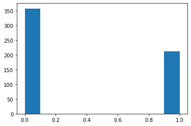

```python
plt.hist(data['diagnosis'])
```

To support further analysis, I replace diagnosis values M and B with numeric values 1 and 0 and chose attributes.

```python
attributes = list(data.columns[1:11])
data_M = data[data['diagnosis'] == 1]
data_B = data[data['diagnosis'] == 0]
```

### 3.2 Histogram of different factors

A histogram is a graphical representation that organizes a group of data points into user-specified ranges.

Here we use histograms to show the pattern of different factors with diagnosis. The goal is to find some correlations between the factors and the diagnosis. Since in this dataset our variable of interest is a categorical value. I tried to find the difference in distribution of the factors in two types of diagnosis. Therefore, if a factor's histogram have different patterns or distributions, it means it could be a potential determinant of the diagnosis when we perform testing and machine learning later.

The blue histograms are the malignant breast tumor distribution adn the orange histograms are the benign breast tumor distribution according to different factors.

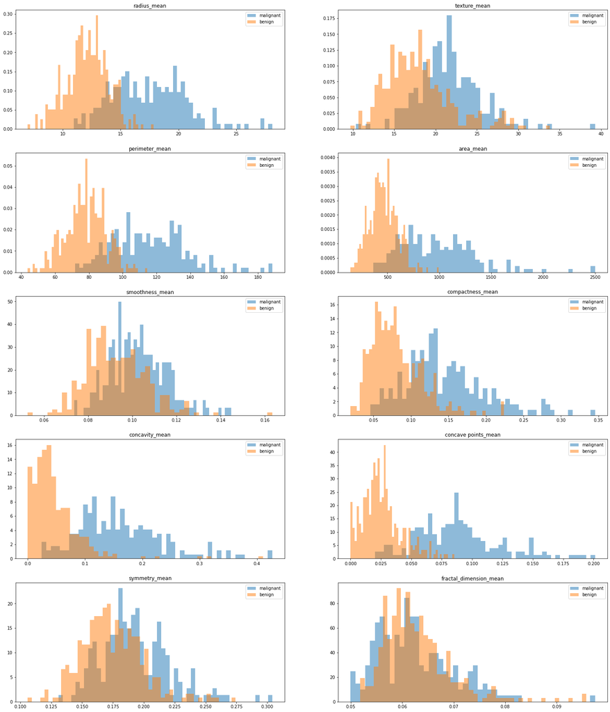

```python
plt.figure(figsize=(25,30))
for attribute,index in zip(attributes,range(1,11)):
    plt.subplot(5,2,index)
    plt.hist(data_M[attribute], alpha = 0.5, label = 'malignant', density = True, bins = 50)
    plt.hist(data_B[attribute], alpha = 0.5, label = 'benign', density = True, bins = 50)
    plt.title(attribute)
    plt.legend()
plt.show()
```

#### Therefore, we can clean the data based on our observations, save variables that are correlated and drop variables that are not helpful in this case.

```python
data_clean = data[['diagnosis','radius_mean','perimeter_mean','area_mean','compactness_mean','concavity_mean','concave points_mean']]
data_clean.head()
```

|  | diagnosis | radius_mean | perimeter_mean | area_mean | compactness_mean | concavity_mean | concave points_mean |
| --- | --- | --- | --- | --- | --- | --- | --- |
| 0 | 1 | 17.99 | 122.80 | 1001.0 | 0.27760 | 0.3001 | 0.14710 |
| 1 | 1 | 20.57 | 132.90 | 1326.0 | 0.07864 | 0.0869 | 0.07017 |
| 2 | 1 | 19.69 | 130.00 | 1203.0 | 0.15990 | 0.1974 | 0.12790 |
| 3 | 1 | 11.42 | 77.58 | 386.1 | 0.28390 | 0.2414 | 0.10520 |
| 4 | 1 | 20.29 | 135.10 | 1297.0 | 0.13280 | 0.1980 | 0.10430 |

### 3.3 Heatmap & Correlations

In this part we want to generate heatmaps to show the correlation between each pair of factors in the dataset. A heat map (or heatmap) is a data visualization technique that shows magnitude of a phenomenon as color in two dimensions. The correlation heatmap shows the magnitude of correaltions and gives us an overview of the relationships in the features of the dataset. This is useful when we want to find out linear relationships. Although for this dataset, we have categorical values as our variable of interest and therefore we would not use a linear regression model, the heatmap still provide information about the relationships of features that could help us later to avoid multicolinearity.

The following heatmap shows all the magnitudes of all correlations in the dataset.

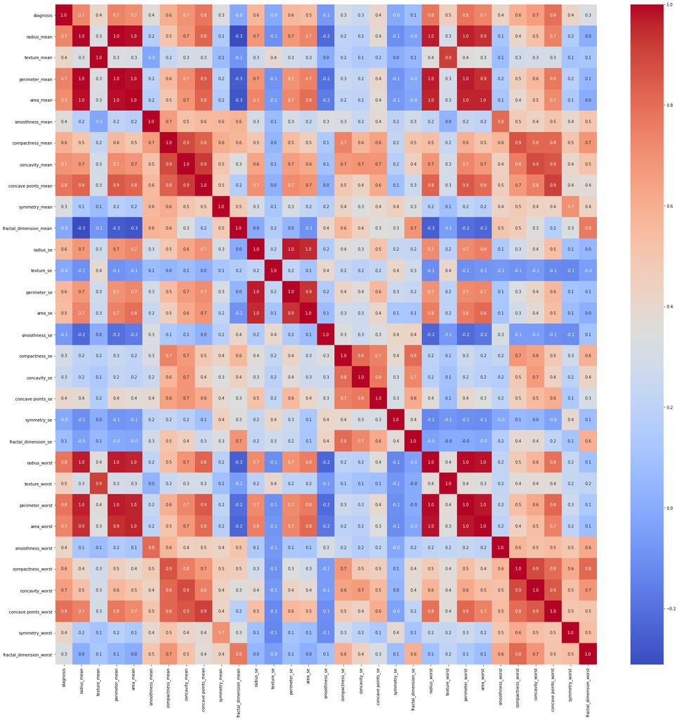

```python
plt.figure(figsize = (30, 30))
corr = data.corr()
sns.heatmap(corr,annot = True, fmt = '.1f', cmap = 'coolwarm')
plt.show()
```

Since there are many features not helpful in our analysis, I generated another heatmap that contains only the correlation between the factors that might be helpful in classification. Since we will need to use these features later in testing and machine learning, it is necessary to know there corelations to avoid multicolinearity.

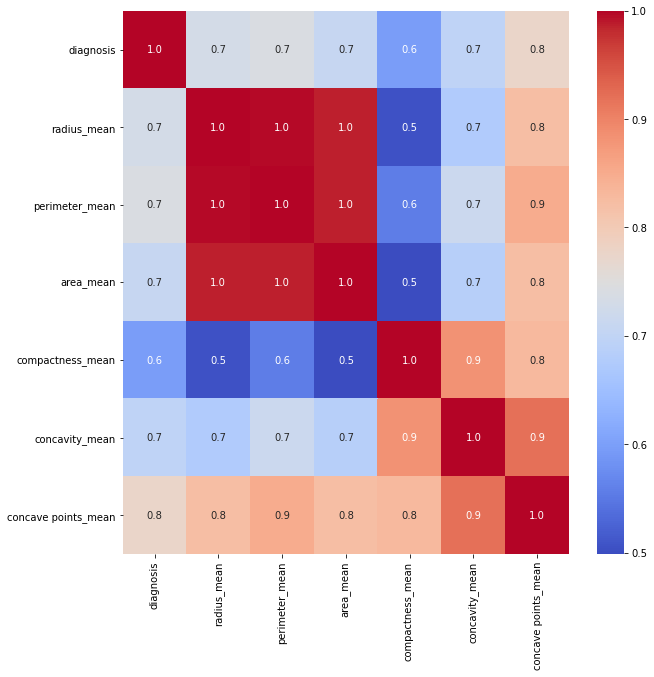

```python
plt.figure(figsize = (10, 10))
corr = data_clean.corr()
sns.heatmap(corr,annot = True, fmt = '.1f', cmap = 'coolwarm')
plt.show()
```

### 3.4 Scatter Plots & Distribution

In this part I made several scatter plots of the features. Scatter plot is another way of visualization to reveal relationships or association between two variables. Here I chose the radius_mean vs. texture_mean; radius_mean vs. compactness_mean; and radius_mean vs. concavity_mean because they can give us a more general and clean visualization.

```
<function matplotlib.pyplot.show(close=None, block=None)>
```

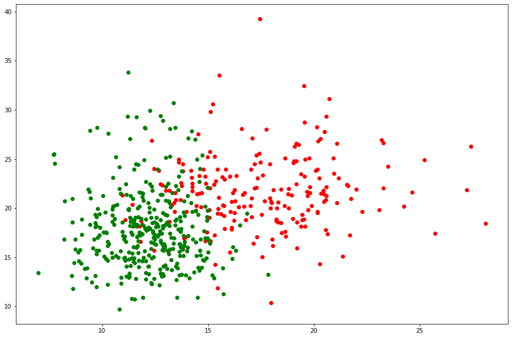

```python
plt.figure(figsize = (15, 10))
plt.scatter(x = data_M['radius_mean'], y = data_M['texture_mean'], c = 'red')
plt.scatter(x = data_B['radius_mean'], y = data_B['texture_mean'], c = 'green')
plt.show
```

We can see from this scatter plot the melignant tumor and benign tumor have a different distribution and apparently melignant tumor generally have a higher radius_mean and texture_mean

```
<function matplotlib.pyplot.show(close=None, block=None)>
```

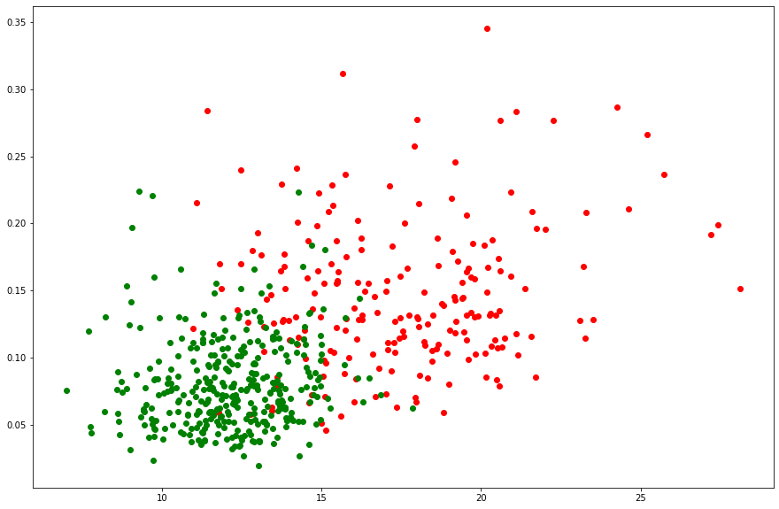

```python
plt.figure(figsize = (15, 10))
plt.scatter(x = data_M['radius_mean'], y = data_M['compactness_mean'], c = 'red')
plt.scatter(x = data_B['radius_mean'], y = data_B['compactness_mean'], c = 'green')
plt.show
```

We can see from this scatter plot the melignant tumor and benign tumor have a different distribution and apparently melignant tumor generally have a higher radius_mean and compactness_mean

```
<function matplotlib.pyplot.show(close=None, block=None)>
```

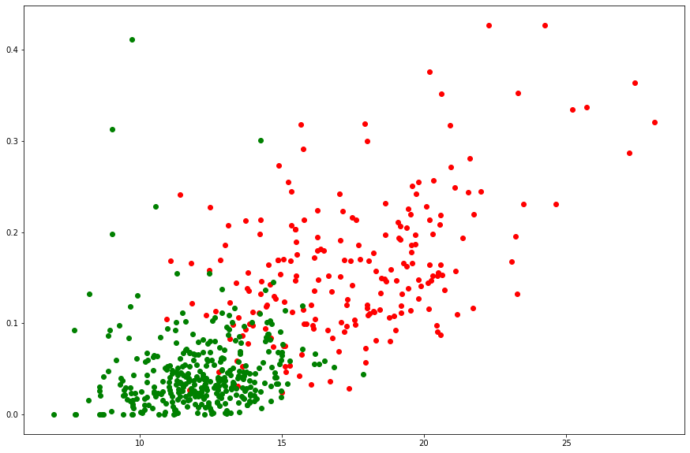

```python
plt.figure(figsize = (15, 10))
plt.scatter(x = data_M['radius_mean'], y = data_M['concavity_mean'], c = 'red')
plt.scatter(x = data_B['radius_mean'], y = data_B['concavity_mean'], c = 'green')
plt.show
```

We can see from this scatter plot the melignant tumor and benign tumor have a different distribution and apparently melignant tumor generally have a higher radius_mean and concavity_mean

#### Here is the end of our data visualization and analysis. Based on the histogram and scatter plot we can conclude that melignant tumor and benign tumor have different distributions and feature values under features including radius_mean, perimeter_mean, area_mean, compactness_mean, concavity_mean, concave points_mean.

#### Moreover, based on the heatmap, we can observe that radius_mean, area_mean, perimeter_mean values have very strong correlations, which makes sense because they dependent on each other; and compactness_mean, concavity_mean, and concave points_mean also have very strong correlations. Therefore we should pay attention to these values when we perform tests and machine learning.

#### Although the scatter plot might not be very useful or give us addition information, it is still an indicator of the distribution and sometimes different visualization methods give us additional information.

## 4. Hypothesis Testing & Machine Learning

For the testing I tried logistic regression model and decision tree model, both of them are widely used for classification of discrete data. The source of classification model is AnalyticsVidhya tutorial.

```python
# Generic function for making a classification model and accessing the performance.
# From AnalyticsVidhya tutorial
def classification_model(model, data, predictors, outcome):
    #Fit the model:
    model.fit(data[predictors],data[outcome])

    #Make predictions on training set:
    predictions = model.predict(data[predictors])

    #Print accuracy
    accuracy = metrics.accuracy_score(predictions,data[outcome])
    print("Accuracy : %s" % "{0:.3%}".format(accuracy))

    #Perform k-fold cross-validation with 5 folds
    kf = KFold(n_splits=5,shuffle = True,random_state = 100)
    error = []
    for train, test in kf.split(traindf):
        # Filter training data
        train_predictors = (data[predictors].iloc[train,:])

        # The target we're using to train the algorithm.
        train_target = data[outcome].iloc[train]

        # Training the algorithm using the predictors and target.
        model.fit(train_predictors, train_target)

        #Record error from each cross-validation run
        error.append(model.score(data[predictors].iloc[test,:], data[outcome].iloc[test]))

        print("Cross-Validation Score : %s" % "{0:.3%}".format(np.mean(error)))

    #Fit the model again so that it can be refered outside the function:
    model.fit(data[predictors],data[outcome])
```

Here we perform a logistic regression analysis using all the features we find that are related to cancer diagnosis.

```python
traindf, testdf = train_test_split(data_clean, test_size = 1)
predictor_var = ['radius_mean','perimeter_mean','area_mean','compactness_mean','concavity_mean', 'concave points_mean']
outcome_var='diagnosis'
model=LogisticRegression()
classification_model(model,traindf,predictor_var,outcome_var)
```

```
Accuracy : 89.789%
Cross-Validation Score : 92.982%
Cross-Validation Score : 91.667%
Cross-Validation Score : 91.228%
Cross-Validation Score : 90.324%
Cross-Validation Score : 89.427%
```

We already verified some multicolinearity between some of the variables. For instance, the radius_mean, perimeter_mean and area_mean have very strong correlation (0.9, 1.0), we should perform the test with only one feature. Same for the concavity_mean, concave points_mean, and compactness. Therefore let's try with radius_mean, concavity_mean.

```python
predictor_var = ['radius_mean', 'concavity_mean']
model=LogisticRegression()
classification_model(model,traindf,predictor_var,outcome_var)
```

```
Accuracy : 88.732%
Cross-Validation Score : 92.982%
Cross-Validation Score : 91.228%
Cross-Validation Score : 90.643%
Cross-Validation Score : 89.885%
Cross-Validation Score : 88.545%
```

The test have a similar prediction accuracy and cross-validation score.

```python
predictor_var = ['radius_mean']
model=LogisticRegression()
classification_model(model,traindf,predictor_var,outcome_var)
```

```
Accuracy : 87.852%
Cross-Validation Score : 91.228%
Cross-Validation Score : 89.474%
Cross-Validation Score : 89.181%
Cross-Validation Score : 88.346%
Cross-Validation Score : 87.137%
```

Now, let's do the same test with decision tree model. Again, we perform three tests, one including all the features, another one with two features that are not strongly correlated, and finally a single predictor variable.

```python
predictor_var = ['radius_mean','perimeter_mean','area_mean','compactness_mean', 'concavity_mean', 'concave points_mean']
model = DecisionTreeClassifier()
classification_model(model,traindf,predictor_var,outcome_var)
```

```
Accuracy : 100.000%
Cross-Validation Score : 90.351%
Cross-Validation Score : 89.035%
Cross-Validation Score : 89.766%
Cross-Validation Score : 89.006%
Cross-Validation Score : 89.081%
```

```python
predictor_var = ['radius_mean', 'concavity_mean']
model = DecisionTreeClassifier()
classification_model(model,traindf,predictor_var,outcome_var)
```

```
Accuracy : 100.000%
Cross-Validation Score : 87.719%
Cross-Validation Score : 87.719%
Cross-Validation Score : 88.889%
Cross-Validation Score : 88.791%
Cross-Validation Score : 88.378%
```

```python
predictor_var = ['radius_mean']
model = DecisionTreeClassifier()
classification_model(model,traindf,predictor_var,outcome_var)
```

```
Accuracy : 95.775%
Cross-Validation Score : 85.965%
Cross-Validation Score : 85.088%
Cross-Validation Score : 86.257%
Cross-Validation Score : 85.489%
Cross-Validation Score : 83.790%
```

## 5. Conclusion

In this project, we went through different steps of the data science pipeline. The tutorial begins with data collection and organization. Although in this project the dataset does not have any missing values, it is important to check and clean data before doing any analysis. The second stage is data visualization and exploratory data analysis. In this stage we should use as many visualization methods as possible to get enough information about the data. For the data analysis, we should focus on the testing and machine learning part to make sure that our analysis will be useful and related. Moreover, it is important to check for the multicolinearity and avoid deviant data.

Using the project data as an example: the goal is to classify breast tumor based on different features. First we want to clean and organize data so that the features left can be helpful and distinct from each other. To classify and predict the tumor, we need to find the difference between two types of tumor using features given. Therefore I chose to do histogram and scatter plot on both diagnosis distinctively to show the difference in the distribution of the features. Luckily I found several features that may contribute to the classfication. Then I made a heatmap to determine if there is any multicolinearity in these features. Once we get the clean data, we can do hypothesis testing and prediction using different testing models.

The reason why I choose this dataset is that, my STAT440 group used this dataset to generate different sampling methods. Therefore I am familiar with this dataset. More importantly, breast cancer is a serious disease. If there is a way to make predictions on disease or symptoms, we can find a way to prevent or protect people from illness. I hope one day data science can be used in all the fields to benefit people and the whole world.

## 6. Related Links

Dataset: https://www.kaggle.com/uciml/breast-cancer-wisconsin-data / https://archive.ics.uci.edu/ml/datasets/Breast+Cancer+Wisconsin+%28Diagnostic%29

Classification_model: https://www.analyticsvidhya.com/blog/2016/01/complete-tutorial-learn-data-science-python-scratch-2/